# Severe Weather Events in the United States: Decisive Reasons

Eduardo B. Díez

July 23, 2014

# Synopsis

```
Using the Severe Weather Data (N=902297) from the National Oceanic and Atmospheric Administration, we examined  which types of events are most harmful to population health and which have the greatest economic  outcomes during the years 1950 to 2011.

Significant differences were observed between the events with greatest consequences to the population healt and to the economy.

Visually inspecting the tabulated data and graphs leads us to affirm that floods are the major causes of damage to property and crops, and tornadoes are responsible for large numbers of fatalities and injuries.
```

# Introduction

This report relates to explore the NOAA [3] Storm Database looking for those weather events that are detrimental to population’s health as well as those who have the greatest economic consequences.

Few variables from the dataset were used and transformed to obtain a wide table, with which to display a couple of plots giving response to the issues this report deals. So, the output of the R-code developed and included in § Data Processing, is conformed by one table and two plots that the interested reader could find at § Results

To complete the Peer Assessment 2 as requested for the course **Reproducible Research** by Roger D. Peng, Jeff Leek and Brian Caffo was used the [RStudio](http://www.rstudio.com/) markdown facilities to generate PDFs files —this one you are reading now— directly from RStudio with [Rmarkdown](http://rmarkdown.rstudio.com/) with [Knitr](http://cran.rstudio.com/web/packages/knitr/index.html) and the additional installation of [MiK$\TeX$](http://miktex.org/) —a $\LaTeX$ flavor for Windows systems— that RStudio use to create a .tex fil e $\LaTeX$ starting from a .Rmd file[^1] that knit convert into a .md file, and then, [pandoc](https://github.com/jgm/pandoc/releases) convert the .md into a .tex file and finally, MiK$\TeX$ construc a PDFs output file from the .tex. All this process from inside RStudio.

Additionally, and knowing that it is not necessary, the § Appendix B has relevant information about the repository from where to download the Rmarkdown file used to obtain this PDF file the reader is reading now, as well as relates to the latex template used for its construction. Thus, not only the results but also the report itself is reproducible.

# Data

This report makes use of the Storm Data cumulative from 1950 until 2011, an official publication of the National Oceanic and Atmospheric Administration (NOAA) which documents the occurrence of storms and other significant weather phenomena having sufficient intensity to cause loss of life, injuries, significant property damage, and/or disruption to commerce. Really, we’ll use a data set that has been modified slightly, with respect the official one, to make easier to work with it [1, 4, 5]

In addition, it is a partial record of other significant meteorological events, such as record maximum or minimum temperatures or precipitation that occurs in connection with another event. Some information appearing in Storm Data may be provided by or gathered from sources outside the National Weather Service (NWS), such as the media, law enforcement and/or other government agencies, private companies, individuals, etc.

An effort is made to use the best available information but because of time and resource constraints, information from these sources may be unverified by the NWS. Therefore, when using information from Storm Data, customers should be cautious as the NWS does not guarantee the accuracy or validity of the information. Further, when it is apparent information appearing in Storm Data originated from a source outside the NWS (frequently credit is provided)

In order to collect the data, we have not been involved neither in the design of the survey nor in the blocking of confounders. We limited our acting ambit to use the data as they are facilitated. That’s the reason we are involved in a **observational study**, based on data already collected and compiled in the NOAA database.

Any finding derived from the present study could be a *general relation* but not a *causal relation*, even being possible the existence of such causal relation, we cannot conclude it; because we are dealing with an observational study rather than a experimental one.

We summarize all the variables we will use from the original dataset:

|  | OriginalVariables | Type |
| --- | --- | --- |
| 1 | BGN_DATE | Factor |
| 2 | EVTYPE | Factor |
| 3 | FATALITIES | int |
| 4 | INJURIES | int |
| 5 | PROPDMG | num |
| 6 | PROPDMGEXP | Factor |
| 7 | CROPDMG | num |
| 8 | CROPDMGEXP | Factor |

Additionally, new variables are going to be created and we’ll use them to construct the images and data to be displayed in this report and we summarize as follow:

|  | NewVariables | Type |
| --- | --- | --- |
| 1 | BGN_YEAR | int |
| 2 | PROPEXP | num |
| 3 | PROP | num |
| 4 | CROPEXP | num |
| 5 | CROP | num |

# Data Processing

The software tool used is RStudio. The processing of the database begins with the establishment of the working environment, where the whole data was saved after being downloaded from the specified location, so it’s read into the work environment R. Then, a function called multiplot [2] was defined from the begining to be prepared to construct and show a figure with a custom panel.

The transformation of the data started with the BGN_DATE original variable from which the year was extracted and added into the database as a new variable called BGN_YEAR. The process continues with the variable PROPDMGEXP, where the original values were changed by numerical values in order to be used in future as a multiplicative factor, so was saved as a new variable called PROPEXP. We applied the same process to the variable CROPDMGEXP, and so was obtained and saved a new variable called CROPEXP. After the multiplication of both new variables by respectively PROPDMG and CROPDMG, the results were saved as PROP and CROP with values in billion of dollars and million of dollars respectively.

These last two new variables, are going to be used by summing their values grouping them by the diverse of events —all of them represented in the variable EVTYPE— therefore, the resulting data set is conformed by the new variables denominated fatalEvent{int}, injurEvent{int}, propEvent{num}, cropEvent{num} and evidently, EVTYPE{factor} too. The new data set was called **FullData** and it will be the starting point from now on.

Continuing to build a wide table that contains the most relevant, the former for health-related and the latter to economic events. In the first case by grouping the events with at least 100 victims and the last with losses of at least $ 1 million in crops. Thus, we are now ready to obtain and display the Table 1, Figure 1 and Figure 2

In order to allow a more fluent reading of this report, the complete code was moved to § Appendix A, where readers can easily copy/paste and get the table and figures mentioned above. Worth warn that the process of loading and manipulation of data is a time consuming process, leading to need several minutes to complete.

# Results

In Table 1 we obtained a summary of the four totals grouped by events, the latter arranged for a number of victims of at least 100 individuals resulting in an understandable table without oversized.

Rearrangement, respect to the type of event, of the four values we are interested; cases of fatalities and injuries, and also, damages to properties and crop.

|  | Event | Fatalities | Injuries | Property(B-dollars) | Crop(M-dollars) |
| --- | --- | --- | --- | --- | --- |
| 1 | TORNADO | 5633 | 91346 | 56.95 | 414.95 |
| 2 | EXCESSIVE HEAT | 1903 | 6525 | 0.01 | 492.40 |
| 3 | FLASH FLOOD | 978 | 1777 | 16.82 | 1421.32 |
| 4 | HEAT | 937 | 2100 | 0.00 | 401.46 |
| 5 | LIGHTNING | 816 | 5230 | 0.93 | 12.09 |
| 6 | TSTM WIND | 504 | 6957 | 4.48 | 554.01 |
| 7 | FLOOD | 470 | 6789 | 144.66 | 5661.97 |
| 8 | RIP CURRENT | 368 | 232 | 0.00 | 0.00 |
| 9 | HIGH WIND | 248 | 1137 | 5.27 | 638.57 |
| 10 | AVALANCHE | 224 | 170 | 0.00 | 0.00 |
| 11 | WINTER STORM | 206 | 1321 | 6.69 | 26.94 |
| 12 | RIP CURRENTS | 204 | 297 | 0.00 | 0.00 |
| 13 | HEAT WAVE | 172 | 309 | 0.01 | 5.55 |
| 14 | EXTREME COLD | 160 | 231 | 0.07 | 1292.97 |
| 15 | THUNDERSTORM WIND | 133 | 1488 | 3.48 | 414.84 |
| 16 | HEAVY SNOW | 127 | 1021 | 0.93 | 134.65 |
| 17 | EXTREME COLD/WIND CHILL | 125 | 24 | 0.01 | 0.05 |
| 18 | STRONG WIND | 103 | 280 | 0.18 | 64.95 |
| 19 | BLIZZARD | 101 | 805 | 0.66 | 112.06 |
| 20 | HIGH SURF | 101 | 152 | 0.09 | 0.00 |

We note that the leading cause of health risk are tornadoes while floods are causing major damage to the economy. Prominent, among all figures, the huge amount of lost caused by floods to the property over the years that we have studied, with a total sum of roughly 145 billion dollars. We accept this amount because comes from a trusted source such as NOAA, but still, we have found it surprising.

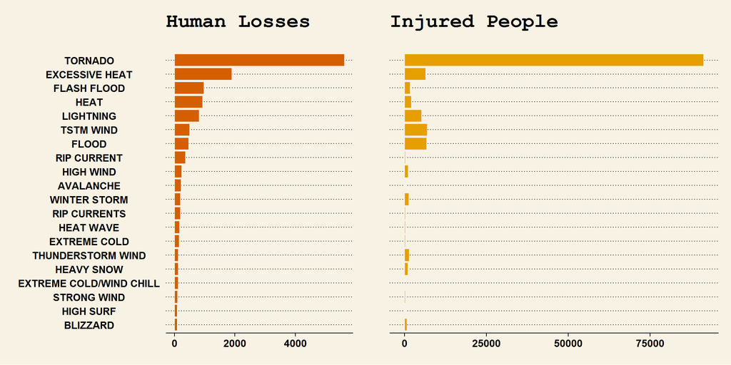

The types of events that are most harmful to population health are show in the above figure and seems that the amount of fatalities and injuries are related —as a anecdotical case— roughly 1:10.

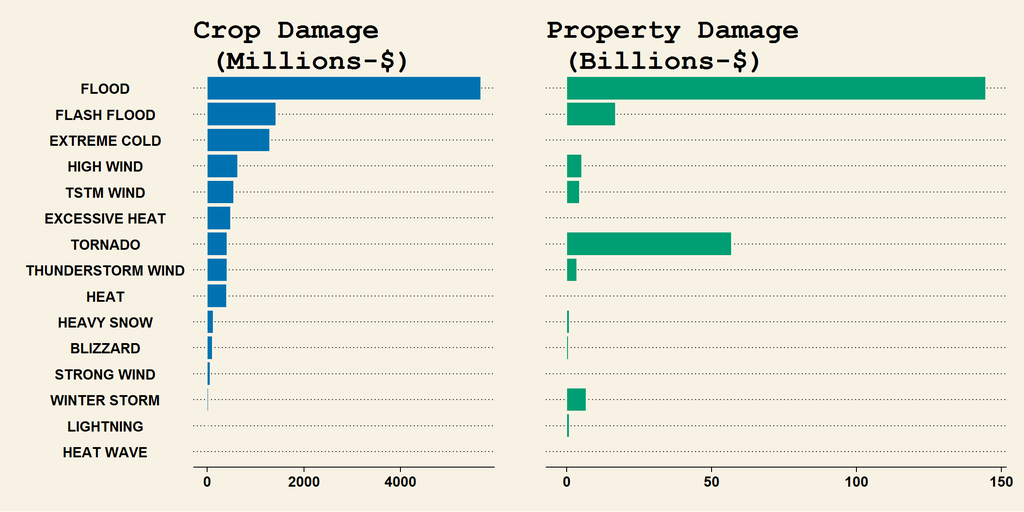

The last figure shows the events with the greatest economic consequences where floods are clearly the most devastating of all events both the damage they cause to crops and properties

# Appendix A

The code that is reproduced below should fully play the manipulation of data, calculations and presentation of the table and the two images used in this report. The code is not intended neither to be nice nor efficient, just get the desired results by giving answer the following two questions; across the United States, which types of events are most harmful with respect to population health, and which have the greatest economic consequences.

```r
# the full listing R code
```

```
# Getting & loading the data
# get the actual working directory
curdir <- getwd()

# set the pointer to the working directory where the original
# dataset is allocated. Change it to fit your particular setting
workingdirectory <- "D:/Cursos/Hopkin/5-Reproducible Research/Project 2"

# set the new working directory
setwd(workingdirectory)

# loading the dataset that is already in the working diractory
myNOAA <- read.csv("./repdatadataStormData.csv.bz2")

# add a variable with only the year, becuase maybe we need it
myNOAA <- subset(myNOAA, select=c("BGN_DATE",
                                  "EVTYPE",
                                  "FATALITIES",
                                  "INJURIES",
                                  "PROPDMG",
                                  "PROPDMGEXP",
                                  "CROPDMG",
                                  "CROPDMGEXP"))


####################
##### function multiplot
####################

# Multiple plot function
# from http://www.cookbook-r.com/Graphs/Multiple_graphs_on_one_page_%28ggplot2%29/
#
# ggplot objects can be passed in ..., or to plotlist (as a list of ggplot objects)
# - cols:   Number of columns in layout
# - layout: A matrix specifying the layout. If present, 'cols' is ignored.
#
# If the layout is something like matrix(c(1,2,3,3), nrow=2, byrow=TRUE),
# then plot 1 will go in the upper left, 2 will go in the upper right, and
# 3 will go all the way across the bottom.
#
```

[output cut: 390 more lines]

```
# also the chunk save the image as a pdf.

multiplot(g4, g3, cols=2)

# save it
png(file = "./myproject2_files/figure-latex/PlotTwo.png",
    width = 960,
    height = 480,
    units = "px",
    pointsize = 12,
    bg = "transparent")

multiplot(g4, g3, cols=2)

dev.off() -> trashcan
```

# Appendix B

The purpose of this addition is to provide an easy way to completely replicate the project, not only the calculations, tables and images, but also to get the final PDF file.

We start by indicating the environment and the software versions we used apart from the RStudio Version 0.98.726;

```
## [1] "RStudio Version 0.98.726"
```

Some times there are troubles to get access to RPubs.com —as it was the case for this submission, being impossible to get upload a HTML file— so to produce a PDF that can be upload basically anyway was the decision for the submission of this project. We was alerted, already, in the instruction for the project:

> **NOTE**[4]**:** If you are having trouble connecting with RPubs due to proxy-related or other issues, you can upload your final analysis document file as a PDF to Coursera instead.

There are several files in the repository where to download all of them to inspect, run or even used discretionally.

- *default.tex* is the LaTeX template to use. It has two minor changes with respect to the original that RStudio + Knit + Rmarkdown install at origin. The first is an additional library in the preamble `\usepackage{booktabs}` to use if needed —as in our case— for the construction of LaTeX tables with the function xtable(). If reader do not desire to make this change in the default.tex can use the R code as showed for the table: `myLatexTable <- print(xtable(tmpTABLE, caption=myCaption), type='latex', comment = FALSE)` with a minimum change with respect the one showed in this report that made use of `booktabs=TRUE` as an additional option in the xtable() aformentioned and also was scaled to give a better look, resulting finally as: `myLatexTable <- print(xtable(tmpTABLE, caption=myCaption), type='latex', booktabs=TRUE, comment = FALSE, scalebox=0.75)`. The second change is relate to have the possibility to change the name of the ‘abstract’ to any other tittle as in our case to ‘Synopsis’. That was done by a new variable for the heading of the Yaml style in the beggining of the Rmarkdown document called `abstract-title` giving the final code where the lines 162, 163 and 164 were added to the original file —again, if reader do not want to touch the original template can remove or comment the line `abstract-title: Synopsis` in the Rmarkdown heading:

> > > ```
> > > . . .
> > >  161 $if(abstract)$
> > > *162 $if(abstract-title)$
> > > *163 \renewcommand{\abstractname}{$abstract-title$}
> > > *164 $endif$
> > >  165 \begin{abstract}
> > >  166 $abstract$
> > >  167 \end{abstract}
> > >  168 $endif$
> > > . . .
> > > ```

- *proj2.Rmd* is the productor of this project and this file, is a long one due, basically, to the incorparation of the full list of the R-code in § Appendix A. The latter was made by copy/paste the whole code after the generation of the final .tex file from the original chunks inside the document with the `echo=TRUE` option, then, the option was changed to `echo=FALSE` in order to make a fluent writing without any chunk code in between. Only one manual edition was done. It’s related to the references or works cited; any tool —bibliatex, natbib or the one used in this file pandoc-citedpro— usually insert the citations at the end of the documents. Latex normally need several —normally three— manual instructed compilations to get everything in place the document. With the pandoc-citepro, incorporated in the Rstudio installation with the knit and Rmarkdown libraries, the citations are edited inside the .tex file, so, we can copy and move it in any other place, for example above the first appendix, without any trouble in the compilation time of the final PDF. The resulting bibliography is not as good looking as the one obtained directly from the latex packages bibliatex or natbib but it is easy, clean and sufficiently good with the fantastic value-add to be move very easy any place inside the document. The bibliography items are also edited inside the own .Rmarkdown file with a pure Yaml heading style.

Those files are located in this [GitHub](https://github.com/EduardoDiezBaez/RepData_PeerAssessment2) repository and also the PDF submited and maybe some other extra of last time.

# Works cited

[1]CODEBOOK. NATIONAL WEATHER SERVICE INSTRUCTION 10-1605: 2007. *http://www.ncdc.noaa.gov/stormevents/pd01016005curr.pdf*. Accessed: 2014-07-10.

[2]Multiple Graphs On One Page (ggplot2). FUNCTION CODE OF MULTIPLOT: 2014. *http://www.cookbook-r.com/Graphs/Multiple_graphs_on_one_page_(ggplot2)/*. Accessed: 2014-07-17.

[3]Severe Weather Data: 2012. *http://www.ncdc.noaa.gov/data-access/severe-weather*. Accessed: 2014-07-15.

[4]Storm data for peer assessment 2 - Course: Reproducible Research. (restricted access, only for COURSERA students): 2014. *https://class.coursera.org/repdata-004/human_grading/view/courses/972143/assessments/4/submissions*. Accessed: 2014-07-10.

[5]Storm database.: 2012. *https://d396qusza40orc.cloudfront.net/repdata%2Fdata%2FStormData.csv.bz2*. Accessed: 2014-07-10.